# Weather Modeling

However, the model struggles to classify Chicago, placing it roughly equally as Cold (correct), Cold-MI, Lincoln, and Newark. This suggests cold-weather cities may be predicted on specific anomalies of 2016 (e.g., where the cold snaps hit). More data may help the model generalize better, specifcally to separate recurring and generalizable climate features of Chicago from weather anomalies that happened to hit Chicago in 2016.

Suppose that models are run on all 2015-2017 data for Chicago, Las Vegas, New Orleans, and San Diego:

```r
# Create the subset for Chicago, Las Vegas, New Orleans, San Diego (should have 2015, 2016, 2017)
sub_2015_2017_data <- modData %>%
    filter(str_sub(source, 1, 4) %in% c("kord", "klas", "kmsy", "ksan")) %>%
    mutate(city=str_replace(locale, pattern=" .\\d{4}.", replacement=""))

# Check that proper locales are included
sub_2015_2017_data %>%
    count(city, locale)
```

```
## # A tibble: 12 x 3
##    city            locale                     n
##    <chr>           <chr>                  <int>
##  1 Chicago, IL     Chicago, IL (2015)      8728
##  2 Chicago, IL     Chicago, IL (2016)      8767
##  3 Chicago, IL     Chicago, IL (2017)      8740
##  4 Las Vegas, NV   Las Vegas, NV (2015)    8727
##  5 Las Vegas, NV   Las Vegas, NV (2016)    8770
##  6 Las Vegas, NV   Las Vegas, NV (2017)    8664
##  7 New Orleans, LA New Orleans, LA (2015)  8727
##  8 New Orleans, LA New Orleans, LA (2016)  8767
##  9 New Orleans, LA New Orleans, LA (2017)  8723
## 10 San Diego, CA   San Diego, CA (2015)    8737
## 11 San Diego, CA   San Diego, CA (2016)    8762
## 12 San Diego, CA   San Diego, CA (2017)    8744
```

```r
# Run random forest for 2015-2017 data
rf_types_2015_2017_TDmcwha <- rfMultiLocale(sub_2015_2017_data,
                                            vrbls=c("TempF", "DewF",
                                                    "month", "hr",
                                                    "minHeight", "ceilingHeight",
                                                    "WindSpeed", "predomDir",
                                                    "modSLP"
                                                    ),
                                            locs=NULL,
                                            locVar="city",
                                            pred="city",
                                            ntree=25,
                                            seed=2006221334,
                                            mtry=4
                                            )
```

```
##
## Running for locations:
## [1] "Chicago, IL"     "Las Vegas, NV"   "New Orleans, LA" "San Diego, CA"
```

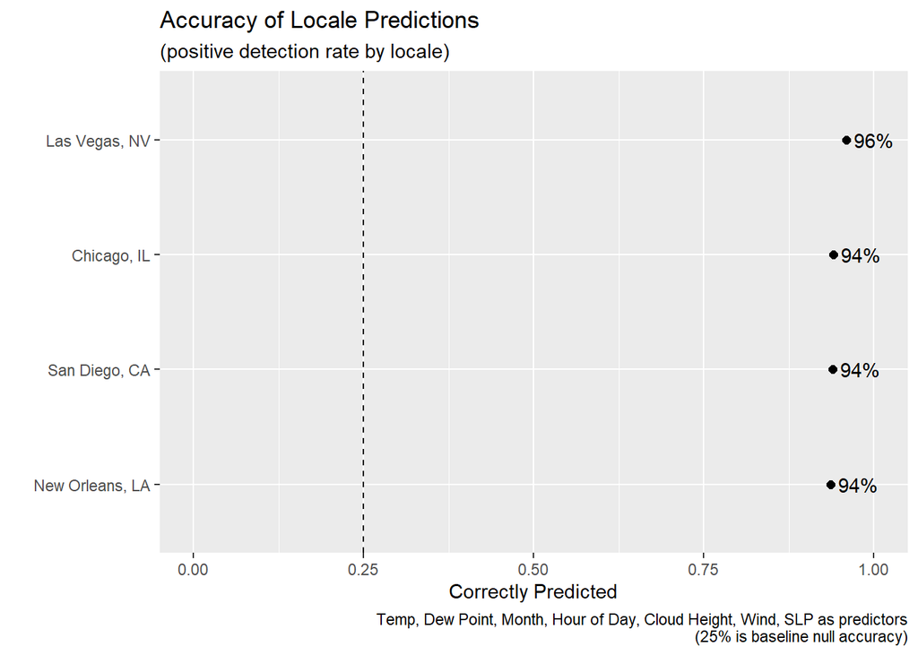

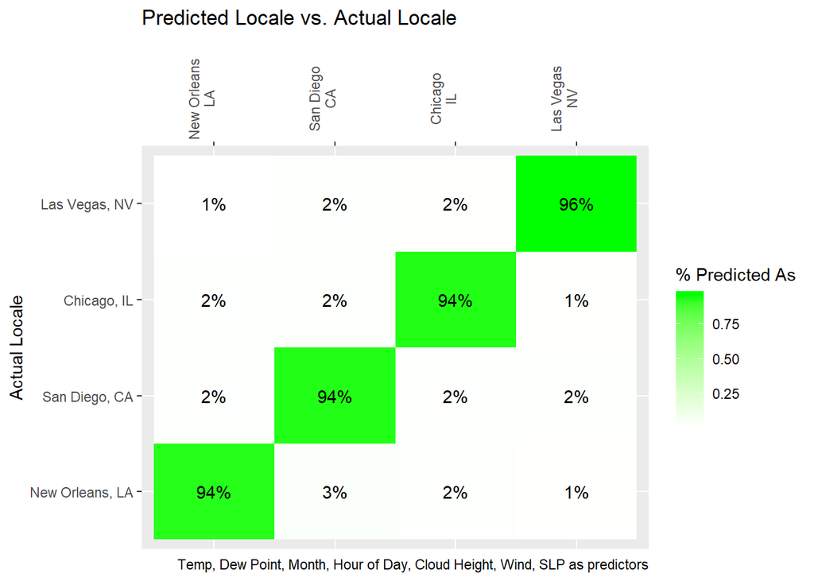

```
## # A tibble: 16 x 5
##    locale          predicted       correct     n     pct
##    <fct>           <fct>           <lgl>   <int>   <dbl>
##  1 Chicago, IL     Chicago, IL     TRUE     7473 0.941
##  2 Chicago, IL     Las Vegas, NV   FALSE     110 0.0139
##  3 Chicago, IL     New Orleans, LA FALSE     162 0.0204
##  4 Chicago, IL     San Diego, CA   FALSE     196 0.0247
##  5 Las Vegas, NV   Chicago, IL     FALSE     122 0.0158
##  6 Las Vegas, NV   Las Vegas, NV   TRUE     7434 0.960
##  7 Las Vegas, NV   New Orleans, LA FALSE      49 0.00633
##  8 Las Vegas, NV   San Diego, CA   FALSE     141 0.0182
##  9 New Orleans, LA Chicago, IL     FALSE     158 0.0201
## 10 New Orleans, LA Las Vegas, NV   FALSE      70 0.00891
## 11 New Orleans, LA New Orleans, LA TRUE     7356 0.937
## 12 New Orleans, LA San Diego, CA   FALSE     268 0.0341
## 13 San Diego, CA   Chicago, IL     FALSE     132 0.0168
## 14 San Diego, CA   Las Vegas, NV   FALSE     188 0.0239
## 15 San Diego, CA   New Orleans, LA FALSE     152 0.0194
## 16 San Diego, CA   San Diego, CA   TRUE     7380 0.940
```

```r
evalPredictions(rf_types_2015_2017_TDmcwha,
                plotCaption = "Temp, Dew Point, Month, Hour of Day, Cloud Height, Wind, SLP",
                keyVar="city"
                )
```

Even with a very small forest (25 trees), the model is almost always separating Las Vegas, Chicago, San Diego, and New Orleans. While the climates are very different in these cities, it is striking that the model has so few misclassifications.

How do other cities map against these classifications?

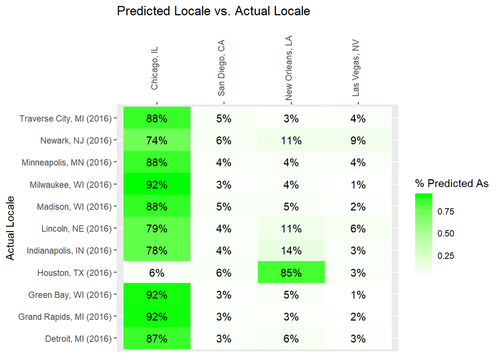

```
## # A tibble: 44 x 4
##    locale                  predicted           n     pct
##    <chr>                   <fct>           <int>   <dbl>
##  1 Detroit, MI (2016)      Chicago, IL      7614 0.873
##  2 Detroit, MI (2016)      Las Vegas, NV     262 0.0300
##  3 Detroit, MI (2016)      New Orleans, LA   553 0.0634
##  4 Detroit, MI (2016)      San Diego, CA     292 0.0335
##  5 Grand Rapids, MI (2016) Chicago, IL      7927 0.918
##  6 Grand Rapids, MI (2016) Las Vegas, NV     133 0.0154
##  7 Grand Rapids, MI (2016) New Orleans, LA   283 0.0328
##  8 Grand Rapids, MI (2016) San Diego, CA     288 0.0334
##  9 Green Bay, WI (2016)    Chicago, IL      7958 0.915
## 10 Green Bay, WI (2016)    Las Vegas, NV      85 0.00978
## # ... with 34 more rows
```

```r
# Predictions on 2015/2017 data
helperPredictPlot(rf_types_2015_2017_TDmcwha$rfModel,
                  df=filter(modData, !(str_sub(source, 1, 4) %in% c("kord", "klas", "kmsy", "ksan"))),
                  predOrder=c("Chicago, IL", "San Diego, CA", "New Orleans, LA", "Las Vegas, NV")
                  )
```

- Houston is most similar to New Orleans as expected
- Milwaukee, Green Bay, and Grand Rapids are all classified 90%+ as Chicago
- Madison, Traverse City, Minneapolis, and Detroit are all classified 85%+ as Chicago
- Lincoln, Indianapolis, and Newark are all “closest” to Chicago, but all show meaningful prediction volumes to New Orleans (these are the three “least cold” of the cold-weather cities in the modeling)

The prediction process is re-run excluding the altimeter (modSLP) data:

```r
# Run random forest for 2015-2017 data (exclude modSLP)
rf_types_2015_2017_TDmcwh <- rfMultiLocale(sub_2015_2017_data,
                                           vrbls=c("TempF", "DewF",
                                                   "month", "hr",
                                                   "minHeight", "ceilingHeight",
                                                   "WindSpeed", "predomDir"
                                                   ),
                                            locs=NULL,
                                            locVar="city",
                                            pred="city",
                                            ntree=25,
                                            seed=2006221334,
                                            mtry=4
                                            )
```

```
##
## Running for locations:
## [1] "Chicago, IL"     "Las Vegas, NV"   "New Orleans, LA" "San Diego, CA"
```

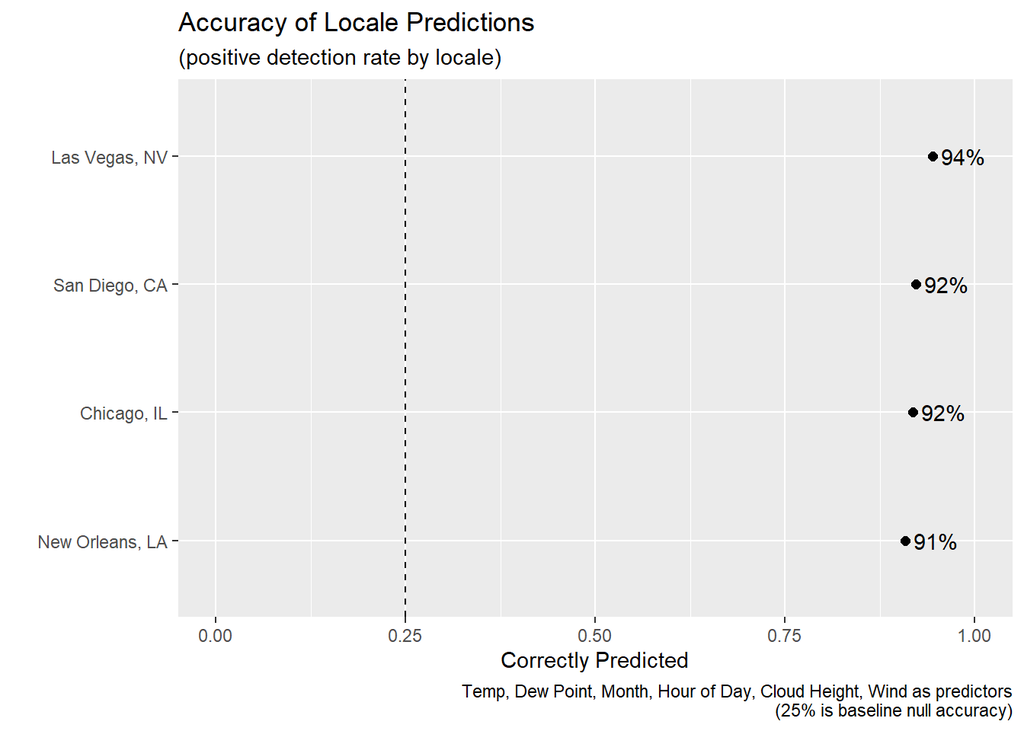

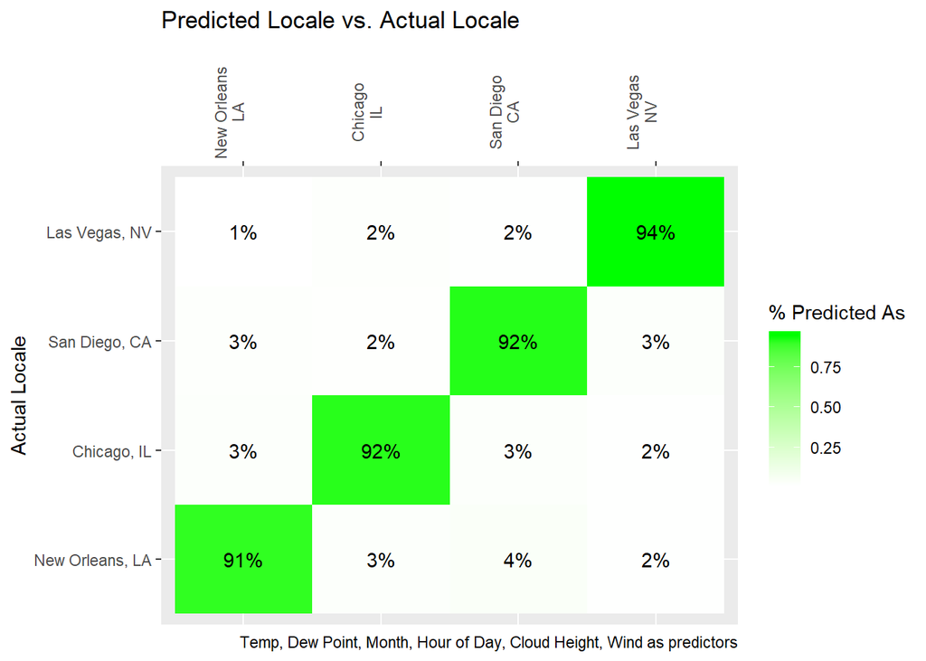

```
## # A tibble: 16 x 5
##    locale          predicted       correct     n    pct
##    <fct>           <fct>           <lgl>   <int>  <dbl>
##  1 Chicago, IL     Chicago, IL     TRUE     7296 0.919
##  2 Chicago, IL     Las Vegas, NV   FALSE     140 0.0176
##  3 Chicago, IL     New Orleans, LA FALSE     263 0.0331
##  4 Chicago, IL     San Diego, CA   FALSE     242 0.0305
##  5 Las Vegas, NV   Chicago, IL     FALSE     186 0.0240
##  6 Las Vegas, NV   Las Vegas, NV   TRUE     7317 0.945
##  7 Las Vegas, NV   New Orleans, LA FALSE      95 0.0123
##  8 Las Vegas, NV   San Diego, CA   FALSE     148 0.0191
##  9 New Orleans, LA Chicago, IL     FALSE     248 0.0316
## 10 New Orleans, LA Las Vegas, NV   FALSE     123 0.0157
## 11 New Orleans, LA New Orleans, LA TRUE     7137 0.909
## 12 New Orleans, LA San Diego, CA   FALSE     344 0.0438
## 13 San Diego, CA   Chicago, IL     FALSE     175 0.0223
## 14 San Diego, CA   Las Vegas, NV   FALSE     231 0.0294
## 15 San Diego, CA   New Orleans, LA FALSE     202 0.0257
## 16 San Diego, CA   San Diego, CA   TRUE     7244 0.923
```

```r
evalPredictions(rf_types_2015_2017_TDmcwh,
                plotCaption = "Temp, Dew Point, Month, Hour of Day, Cloud Height, Wind",
                keyVar="city"
                )
```

Performance drops, since altimeters are meaningfully different in high altitude (Las Vegas) and sea-level (New Orleans and San Diego) locations.

Variable importances are plotted:

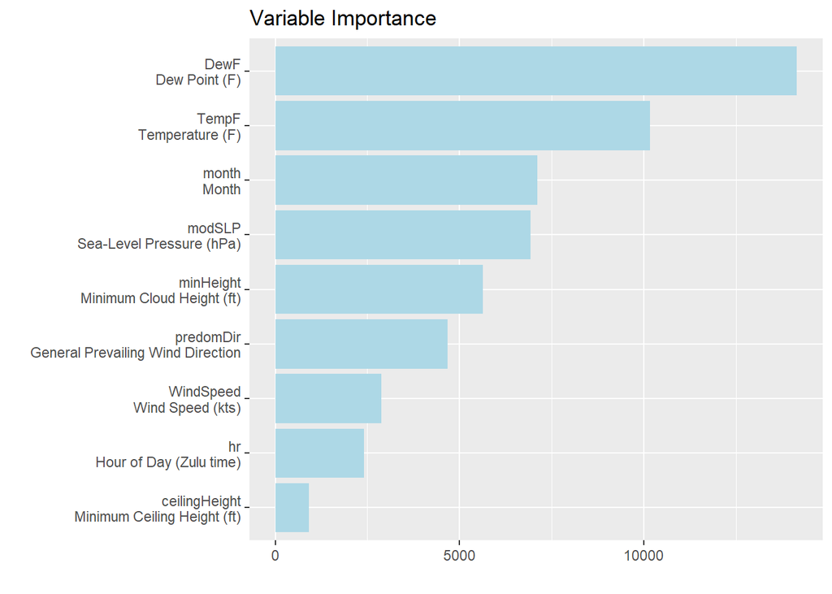

```r
helperPlotVarImp <- function(model, titleAdd="", mapper=varMapper) {

    p1 <- model %>%
        caret::varImp() %>%
        rownames_to_column("predictor") %>%
        ggplot(aes(x=fct_reorder(paste0(predictor, "\n", varMapper[predictor]), Overall), y=Overall)) +
        geom_col(fill="lightblue") +
        labs(x="", y="", title=paste0("Variable Importance", titleAdd)) +
        coord_flip()
    print(p1)

}

helperPlotVarImp(rf_types_2015_2017_TDmcwha$rfModel)
```

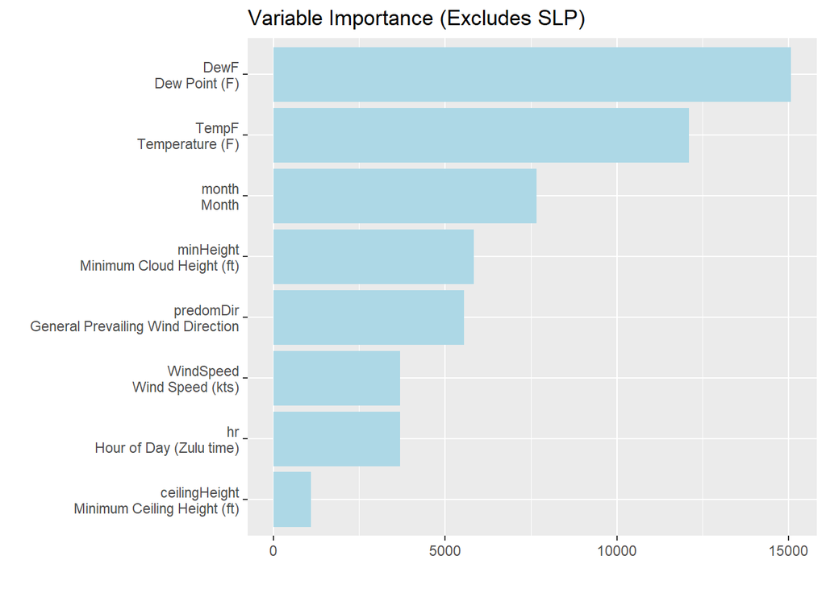

```r
helperPlotVarImp(rf_types_2015_2017_TDmcwh$rfModel, titleAdd=" (Excludes SLP)")
```

Dew point and temperature by month continue to be strong factors for separating the four cities in this analysis. SLP, minimum cloud height, and prevailing wind direction are also meaningful.